# N741 Lecture 5: EDA with `dplyr` and `ggplot2`

Melinda Higgins

February 12, 2018

## Packages needed for today’s lecture:

- `car`
- `tidyverse` - mainly using `dplyr` and `ggplot2`
- `janitor` *(optional)*

## Rmarkdown initial setup options

Create an initial R chunk with `knitr` options to control what is shown or not shown in your final output. Three options are useful to set to FALSE for the final version. These 3 options can be kept as TRUE when debugging initially.

- `echo` - set to TRUE to see your R code in the final document - set to TRUE for homework
- `warning` - set to FALSE so that warnings are hidden
- `message` - set to FALSE to hide messages like when loading packages and such

It is also a good idea to load the packages needed for all of the code run in this RMD (R markdown) document in this first R-code chunk.

```r
# knitr options
knitr::opts_chunk$set(echo = TRUE)
knitr::opts_chunk$set(warning = FALSE)
knitr::opts_chunk$set(message = FALSE)

# packages needed for this RMD
library(car)
library(tidyverse)
```

## Naming R code chunks

It is a good practice to give your R code chunks names. That way when you are debugging, it’ll be easier to figure out which section of the document or R-code chunk is failing.

The R-code chunk above is called `setup`.

## Working with `Leinhardt` dataset in `car` package

The `car` package has 51 datasets built into it. One of these datasets is the `Leinhardt` dataset. Type `?car::Leinhardt` at the console to see help details on this dataset. This dataset has 105 rows and 4 columns with observations from nations of the world around 1970. The 4 columns are:

- `income`
- `infant`
- `region`
- `oil`

Load the dataset and take a look at it. We can access the dataset directly using the `View()` command and by referencing the dataset using the `package::dataset` syntax.

OR we can also create a new data object using the `<-` assign command and work with this copy of the dataset in memory to work from.

```r
dataLeinhardt <- car::Leinhardt
```

## Dataset object

Look at the type of object this dataset is and the structure of the data - the types of variables in the dataset.

```r
class(dataLeinhardt)
```

```
## [1] "data.frame"
```

```r
str(dataLeinhardt)
```

```
## 'data.frame':    105 obs. of  4 variables:
##  $ income: int  3426 3350 3346 4751 5029 3312 3403 5040 2009 2298 ...
##  $ infant: num  26.7 23.7 17 16.8 13.5 10.1 12.9 20.4 17.8 25.7 ...
##  $ region: Factor w/ 4 levels "Africa","Americas",..: 3 4 4 2 4 4 4 4 4 4 ...
##  $ oil   : Factor w/ 2 levels "no","yes": 1 1 1 1 1 1 1 1 1 1 ...
```

## Summary of Data

One of the easiest ways to summarize the variables in the dataset is to run the `summary()` command.

```r
summary(dataLeinhardt)
```

```
##      income           infant            region    oil
##  Min.   :  50.0   Min.   :  9.60   Africa  :34   no :96
##  1st Qu.: 123.0   1st Qu.: 26.20   Americas:23   yes: 9
##  Median : 334.0   Median : 60.60   Asia    :30
##  Mean   : 998.1   Mean   : 89.05   Europe  :18
##  3rd Qu.:1191.0   3rd Qu.:129.40
##  Max.   :5596.0   Max.   :650.00
##                   NA's   :4
```

This is ok when the dataset has only a few variables. However, we will often only want summaries of some of the variables in a dataset. Let’s begin using the `dplyr` package to work specific sections of the data we want.

Learn more about `dplyr` at http://dplyr.tidyverse.org/. There is also good overall information at http://stat545.com/topics.html.

## Intro to `dplyr`

The `dplyr` package provides 2 key aspects of working with data in `R`:

- the pipe operator `%>%` and
- verb based functions to take action on your data

The pipe operator `%>%` actually comes from the `magrittr` package which is loaded with `dplyr`. The main benefit of the pipe operator `%>%` is that you can directly reference variables in your dataset without having to use the dollar sign `$` selector.

For example, let’s make a subset of the data for countries in “Asia” using the `filter()` function from `dplyr`. The R-code below can be read as take the Leinhardt dataset and pipe it into the filter function and find only data for countries in the “Asia” region.

```r
dataAsia <- dataLeinhardt %>%
  filter(region == "Asia")
```

Additionally, you can string together a series of commands by simply piping the result from the previous command into the next command. Let’s add the `summary()` function to get the summary statistics for the variables but only for the Asian countries.

```r
dataLeinhardt %>%
  filter(region == "Asia") %>%
  summary()
```

```
##      income           infant            region    oil
##  Min.   :  71.0   Min.   : 10.20   Africa  : 0   no :26
##  1st Qu.: 100.5   1st Qu.: 21.90   Americas: 0   yes: 4
##  Median : 245.5   Median : 50.00   Asia    :30
##  Mean   : 638.9   Mean   : 96.17   Europe  : 0
##  3rd Qu.: 539.2   3rd Qu.:112.15
##  Max.   :3723.0   Max.   :650.00
##                   NA's   :3
```

## Choose variables

Let’s only look at `income` and `infant` and get the summary stats. Use the `select()` function from `dplyr`.

```r
dataLeinhardt %>%
  select(income, infant) %>%
  summary()
```

```
##      income           infant
##  Min.   :  50.0   Min.   :  9.60
##  1st Qu.: 123.0   1st Qu.: 26.20
##  Median : 334.0   Median : 60.60
##  Mean   : 998.1   Mean   : 89.05
##  3rd Qu.:1191.0   3rd Qu.:129.40
##  Max.   :5596.0   Max.   :650.00
##                   NA's   :4
```

## Get specific statistics on the variables you want

Let’s get the mean and standard devaition for the `income` variable.

```r
dataLeinhardt %>%
  summarise(meanIncome = mean(income),
            sdIncome = sd(income))
```

```
##   meanIncome sdIncome
## 1   998.0667 1416.714
```

and we can get the number of observations using the `n()` command in `dplyr`.

```r
dataLeinhardt %>%
  summarise(nObs = n())
```

```
##   nObs
## 1  105
```

## Get summary stats

We can get summary statistics for multiple statistics and multiple variables by using the `summarise_all()` function in `dplyr`. This function is used in conjunction with the `funs()` command to list the functions you want along with any options needed.

```r
dataLeinhardt %>%
  select(income, infant) %>%
  summarise_all(funs(mean, sd))
```

```
##   income_mean infant_mean income_sd infant_sd
## 1    998.0667          NA  1416.714       NaN
```

Notice the `mean` and `sd` for `infant` yields `NA` and `NaN` due to the missing data in the `infant` variable. So, we need to add the option `na.rm=TRUE` to remove missing values before computing the requested statistic.

```r
# add na.rm=TRUE as option to remove
# NAs for the infant variable.
dataLeinhardt %>%
  select(income, infant) %>%
  summarise_all(funs(mean, sd), na.rm=TRUE)
```

```
##   income_mean infant_mean income_sd infant_sd
## 1    998.0667    89.04752  1416.714  90.80171
```

## Complete Cases

Notice that there are 4 countries that do not have data for infant mortality - there are 4 `NA's` for the `infant` variable. Suppose we want to determine how many observations have complete data across all variables in this dataset. Let’s look at the `complete.cases()` function. The result of this function is a vector of TRUE and FALSE for each row/observation that has no missing data across all columns/variables.

Then use the `table()` function to see the tally of the number of TRUE’s and FALSE’s.

```r
completeObs <- complete.cases(dataLeinhardt)
table(completeObs)
```

```
## completeObs
## FALSE  TRUE
##     4   101
```

We can then use this vector of TRUE and FALSE to keep only the complete data. Here are 2 ways to do this.

```r
dataComplete <- dataLeinhardt %>%
  na.omit()

dataComplete <- dataLeinhardt %>%
  filter(complete.cases(.))
```

## Count the amount of missing data

The function `is.na()` is a good way to determine how much missing data there is for any given variable. This again creates a LOGICAL vector of TRUE’s and FALSE’s to indicate if data for the variable specified is missing for that observation or not.

It turns out that you can run functions like `mean()` and `sum()` on LOGICAL vectors. If you run `sum()` on this vector you get the number of missing values. If you run `mean()` you get the proportion of missing data (i.e. the count/total number of observations).

```r
missingInfant <- is.na(dataLeinhardt$infant)
sum(missingInfant)
```

```
## [1] 4
```

```r
mean(missingInfant)
```

```
## [1] 0.03809524
```

## Graphics with `ggplot2`

Let’s look at the distributions of `income` and `infant` mortality. Here is a basic histogram of `income`.

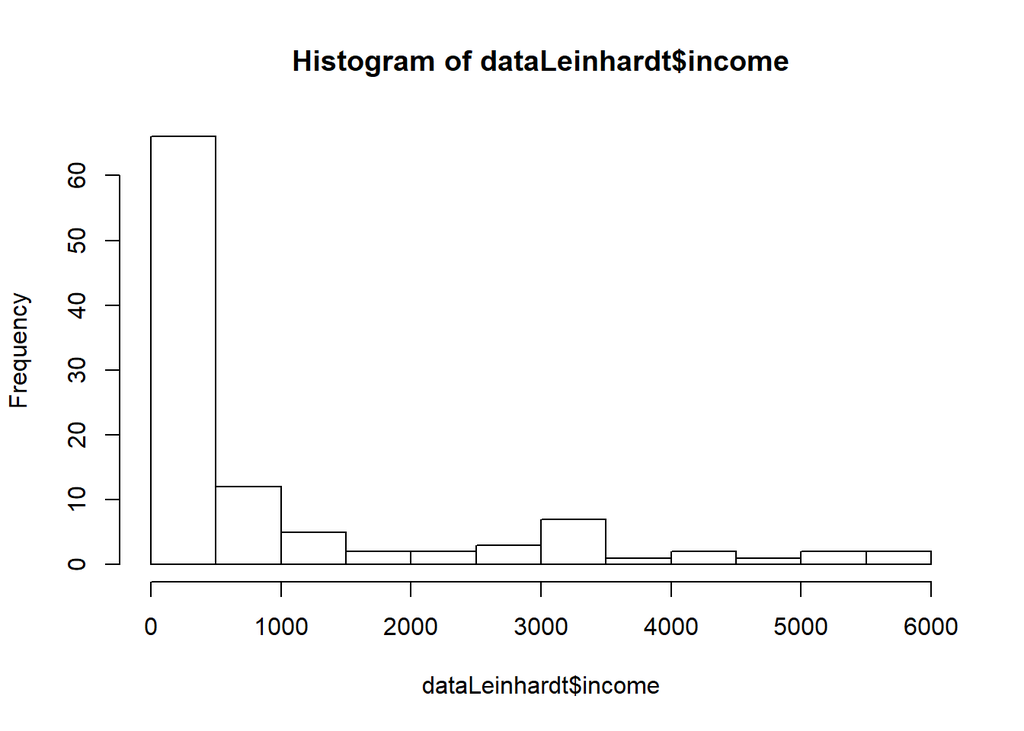

```r
hist(dataLeinhardt$income)
```

Instead let’s use a `ggplot2` approach. First we create a plot with `ggplot()` with the “aesthetics” we need defined. The “aesthetic” we need here is the `income` variable.

Then we add the geometric object layer - these are called `geom`’s. The one we want here is `geom_histogram()`.

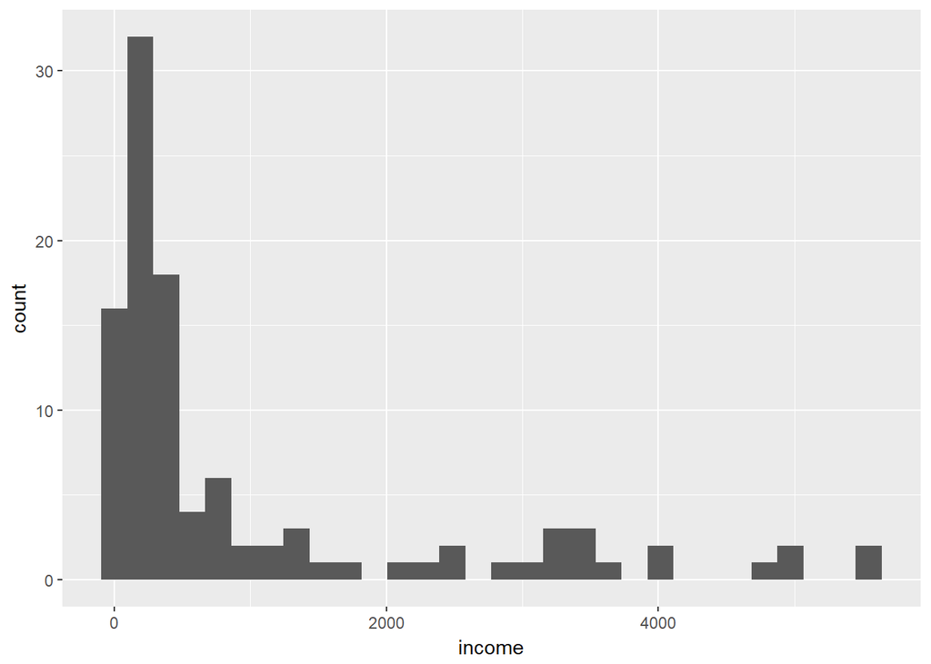

```r
ggplot(dataLeinhardt, aes(income)) +
  geom_histogram()
```

A great website for learning `ggplot2` and seeing worked example on how to create various graphics is the “Cookbook for R” website at http://www.cookbook-r.com/Graphs/.

For example, here is a nice histogram with a density curve overlaid with color - see the 4th histogram plot and associated code at http://www.cookbook-r.com/Graphs/Plotting_distributions_(ggplot2)/. Let’s adapt this code for our histogram of `income`. Basically, change out the dataset name, the variable listed in `aes()` and change the `binwidth` to something more appropriate for this `income` variable. Feel free to play with changing the colors.

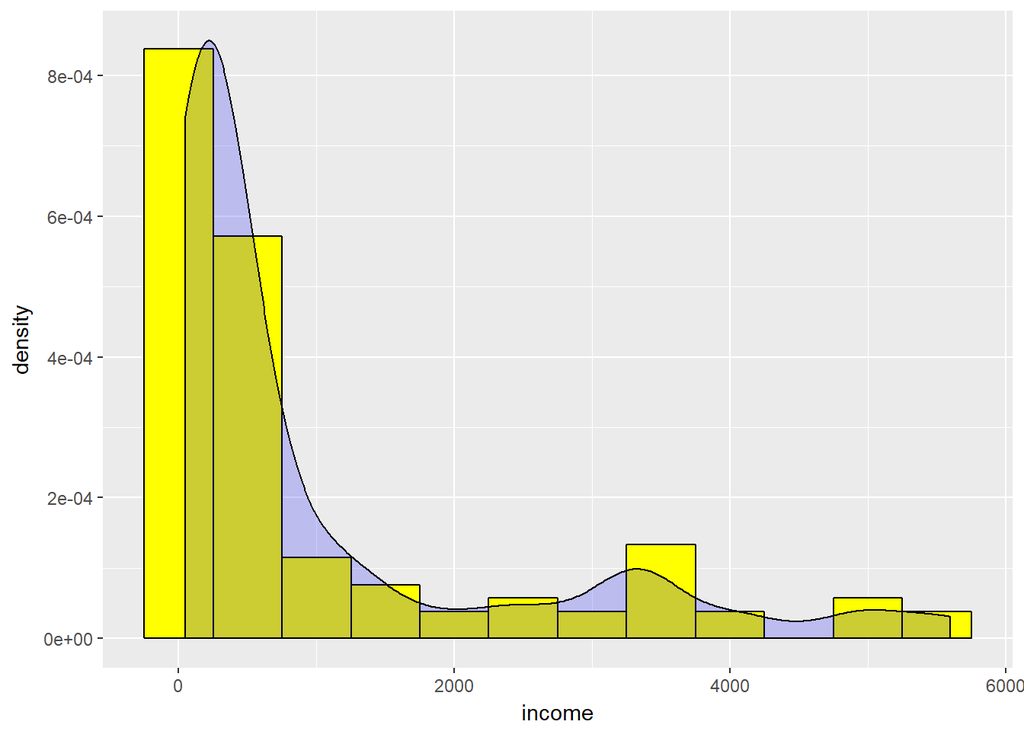

```r
# Histogram overlaid with kernel density curve
ggplot(dataLeinhardt, aes(x=income)) +
    geom_histogram(aes(y=..density..),
                   binwidth=500,
                   colour="black", fill="yellow") +
    geom_density(alpha=.2, fill="blue")
```

## Boxplots by groups

What if we want to look at the income distributions by region. We can do that using the `geom_boxplot()` and updating the `aes()` list.

Again, see examples at http://www.cookbook-r.com/Graphs/Plotting_distributions_(ggplot2)/.

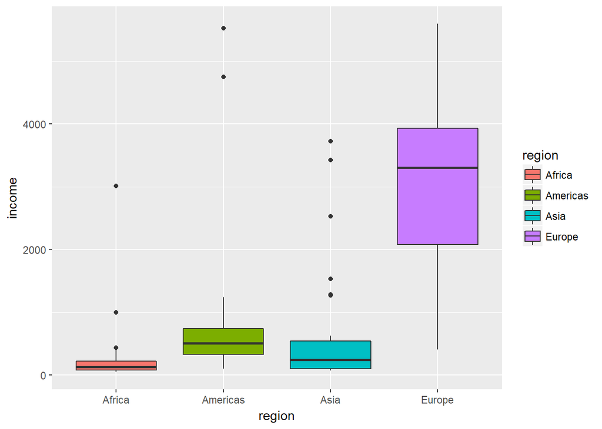

```r
# A basic box with the conditions colored
ggplot(dataLeinhardt,
       aes(x=region, y=income, fill=region)) +
  geom_boxplot()
```

## Transform, Create new variables

The infant mortality rates are very right skewed (longer tail to the right). A possible mathematical transformation of right skewness is to do a log transformation. Let’s create a new variable in the dataset that is the log of the infant mortality rate using the `log()` function from base `R` and the `mutate()` function from `dplyr`.

```r
dataLeinhardt <- dataLeinhardt %>%
  mutate(logInfant = log(infant))
```

Compare these 2 variables using histograms. Notice that the bandwidths are different.

### Original `infant` variable

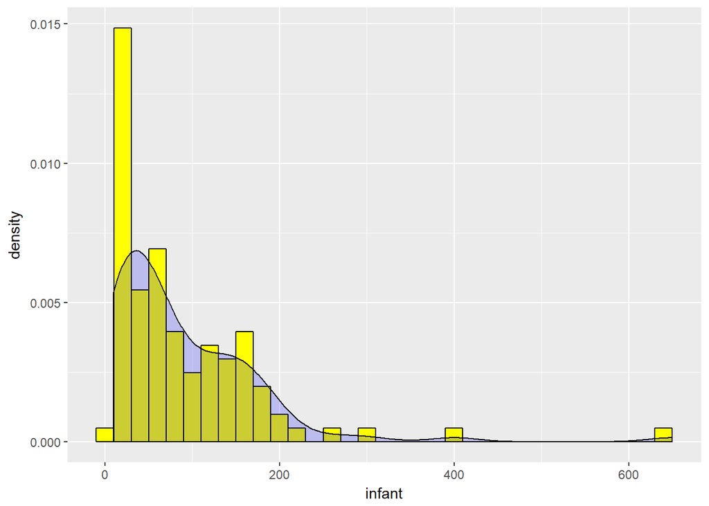

```r
ggplot(dataLeinhardt, aes(x=infant)) +
    geom_histogram(aes(y=..density..),
                   binwidth=20,
                   colour="black", fill="yellow") +
    geom_density(alpha=.2, fill="blue")
```

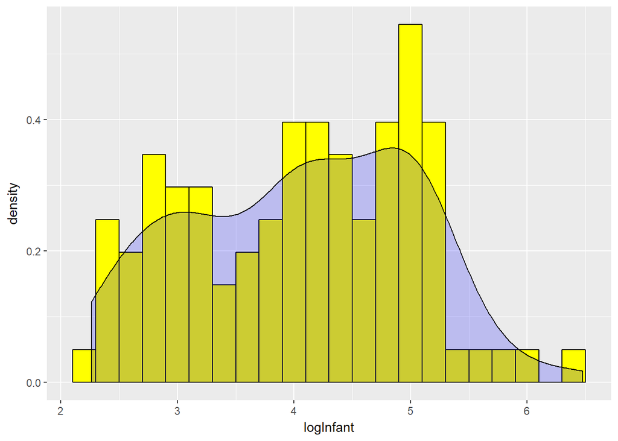

```r
ggplot(dataLeinhardt, aes(x=logInfant)) +
    geom_histogram(aes(y=..density..),
                   binwidth=.2,
                   colour="black", fill="yellow") +
    geom_density(alpha=.2, fill="blue")
```

## Recode data

Suppose we wanted to break the infant mortality rates into low, moderate and high categories. For example, let’s create the following categories based on these infant mortality rates.

### Infant Mortality Categories

| Category | Infant Mortality (rate/1000 live births) |
| --- | --- |
| Low | <50 |
| Moderate | 50 to <100 |
| High | 100 or more |

To do this we’ll create a new variable using the `mutate()` function in `dplyr` AND we’ll also use the `if_else()` function in `dplyr`.

```r
dataLeinhardt <- dataLeinhardt %>%
  mutate(infantcat = if_else(infant<50, "1. Low",
                     if_else(infant<100,
                             "2. Moderate",
                             "3. High",
                             "4. missing"),
                     "4. missing"))
```

Count the number of countries that fall into each category

```r
dataLeinhardt %>%
  count(infantcat)
```

```
## # A tibble: 4 x 2
##     infantcat     n
##         <chr> <int>
## 1      1. Low    41
## 2 2. Moderate    23
## 3     3. High    37
## 4  4. missing     4
```

[OPTIONAL] Here is a nice way to get a formatted table of counts and percents using the `tabyl()` function from the `janitor` package.

```r
# optional - a nice way to get a formatted
# table of the counts for infant categories
library(janitor)
dataLeinhardt %>%
  janitor::tabyl(infantcat)
```

```
##     infantcat  n    percent
## 1      1. Low 41 0.39047619
## 2 2. Moderate 23 0.21904762
## 3     3. High 37 0.35238095
## 4  4. missing  4 0.03809524
```

Run again adding the `knitr::kable()` function when using INSIDE of an RMD document.

```r
dataLeinhardt %>%
  janitor::tabyl(infantcat) %>%
  knitr::kable()
```

| infantcat | n | percent |
| --- | --- | --- |
| 1. Low | 41 | 0.3904762 |
| 2. Moderate | 23 | 0.2190476 |
| 3. High | 37 | 0.3523810 |
| 4. missing | 4 | 0.0380952 |

## Clustered bar chart

Let’s look at these infant mortality rate categories by region by making a clustered bar chart. some examples can be seen at http://www.cookbook-r.com/Graphs/Bar_and_line_graphs_(ggplot2)/#with-x-axis-treated-as-categorical. Scroll to the bottom of the page.

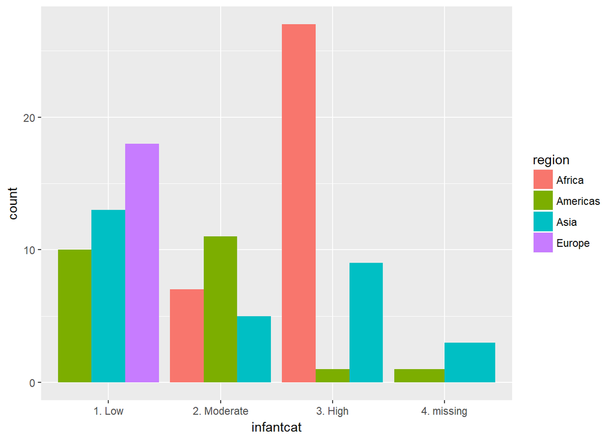

```r
# cluster barchart of infant categories by region
dataLeinhardt %>% ggplot(aes(x=infantcat, fill=region)) +
  geom_bar(position = "dodge")
```

Make the chart again removing the countries with missing infant mortality rates. Use the `is.na()` function and put an exclamation point `!` in front to say find all without missing data, find when NOT TRUE.

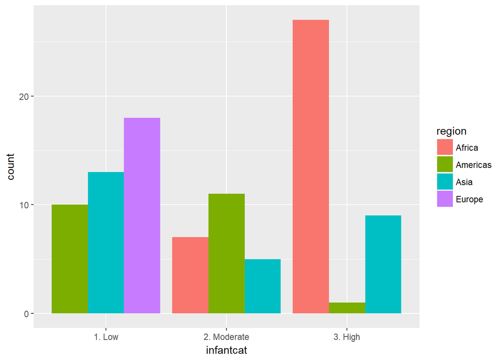

```r
dataLeinhardt %>%
  filter(!is.na(infant)) %>%
  ggplot(aes(x=infantcat, fill=region)) +
  geom_bar(position = "dodge")
```

## Other things to try

1. Go back to the first R-code chunk and change `echo=TRUE` to `echo=FALSE` and see what happens to the output.
2. Install the `Rcmdr` package and then load it by running `library(Rcmdr)` in the Console window - try out using the R Commander package. Learn more at http://www.rcommander.com/.
3. Kahoot Quiz